# Statistical Analysis and Concepts with Python

# Building a linear regression model to predict Median Value home prices

### Define independent and dependent variables

Two models two compare the results of LSTAT and LSTAT_LOG

```python
df.head(1)
```

|  | CRIM | ZN | INDUS | CHAS | NOX | RM | AGE | DIS | RAD | TAX | PTRATIO | B | LSTAT | LSTAT_LOG | Median_Value |
| --- | --- | --- | --- | --- | --- | --- | --- | --- | --- | --- | --- | --- | --- | --- | --- |
| 0 | 0.00632 | 18.0 | 2.31 | 0.0 | 0.538 | 6.575 | 65.2 | 4.09 | 1.0 | 296.0 | 15.3 | 396.9 | 4.98 | 1.788421 | 24.0 |

```python
#LSTAT
L_Y = df[['Median_Value']]
L_X = df[['LSTAT']]

#LSTAT_LOG
LL_Y = df[['Median_Value']] # define dependent variable
LL_X = df[['LSTAT_LOG']] # define independent variable
```

### Split the data for supervised training

Linear regression is a supervised learning model. When training a model using a supervised model the data gets split into two data sets training and testing. The model is first trained on the training data then once the model is trained it can be tested on the test data. Supervised learning allows for the validation of the model because the test data can be compared against the actual data.

```python
#Splitting LSTAT
L_X_train,L_X_test,L_Y_train,L_Y_test = train_test_split(L_X,L_Y,random_state=1)
```

```python
#Splitting LSTAT_LOG
LL_X_train,LL_X_test,LL_Y_train,LL_Y_test = train_test_split(LL_X,LL_Y,random_state=1)
```

You can see from the data below that a random grouping of data has been selected to train the model.

```python
L_X_train.head()
```

|  | LSTAT |
| --- | --- |
| 502 | 9.08 |
| 172 | 14.69 |
| 80 | 5.29 |
| 46 | 14.15 |
| 318 | 10.36 |

```python
print('The number of records in the LSTAT indepedent variable training set is:',len(L_X_train))
print('The number of records in the LSTAT dependent variable training set is :',len(L_Y_train))
print("")
print('The number of records in the LSTAT independent testing set is:',len(L_X_test))
print('The number of records in the LSTAT dependent testing set is',len(L_Y_test))
print("")
print("The model will be trained on approximatey 75% of the data and tested on 25% of the data.")
```

```
The number of records in the LSTAT indepedent variable training set is: 379
The number of records in the LSTAT dependent variable training set is : 379

The number of records in the LSTAT independent testing set is: 127
The number of records in the LSTAT dependent testing set is 127

The model will be trained on approximatey 75% of the data and tested on 25% of the data.
```

**Build and train the model**

```python
#Build and fit the LSTAT model
L_regression_model = LinearRegression()
L_regression_model.fit(L_X_train,L_Y_train)

#Build the LSTAT_LOG model
LL_regression_model = LinearRegression()
LL_regression_model.fit(LL_X_train,LL_Y_train)
```

```
LinearRegression(copy_X=True, fit_intercept=True, n_jobs=None, normalize=False)
```

**Obtaining intercept and coefficent of model**

```python
#LSTAT intercept and coefficent
L_intercept = L_regression_model.intercept_
L_coefficient = L_regression_model.coef_

LL_intercept = LL_regression_model.intercept_
LL_coefficient = LL_regression_model.coef_


print(f'The LSTAT intercept is {L_intercept[0]:.2f} and the LSTAT coefficient is {L_coefficient[0][0]:.2f}')
print(f'The LSTAT_LOG intercept is {LL_intercept[0]:.2f} and the LSTAT_LOG coefficient is {LL_coefficient[0][0]:.2f}')
```

```
The LSTAT intercept is 34.12 and the LSTAT coefficient is -0.91
The LSTAT_LOG intercept is 56.03 and the LSTAT_LOG coefficient is -13.49
```

**Confidence Intervals**

```python
L_X2 =  sm.add_constant(L_X)
LL_X2 = sm.add_constant(LL_X)

L_model = sm.OLS(L_Y,L_X2)
LL_model = sm.OLS(LL_Y,LL_X2)

L_est = L_model.fit()
LL_est = LL_model.fit()
```

```python
print('Based on the linear model and the confidence intervals we can say that with 95% confidence the coefficient of LSTAT\nshould be between -1.02 amd -0.87.')
L_est.conf_int()
```

```
Based on the linear model and the confidence intervals we can say that with 95% confidence the coefficient of LSTAT
should be between -1.02 amd -0.87.
```

|  | 0 | 1 |
| --- | --- | --- |
| const | 33.448457 | 35.659225 |
| LSTAT | -1.026148 | -0.873951 |

```python
print('Based on the linear model and the confidence intervals we can say that with 95% confidence the coefficient of LSTAT_LOG\nshould be between -14.7 and -12.9.')
LL_est.conf_int()
```

```
Based on the linear model and the confidence intervals we can say that with 95% confidence the coefficient of LSTAT_LOG
should be between -14.7 and -12.9.
```

|  | 0 | 1 |
| --- | --- | --- |
| const | 54.564058 | 58.993083 |
| LSTAT_LOG | -14.707356 | -12.959172 |

### Hypothesis Testing

**LSTAT Hypothesis:**

- **Null Hypothesis:** There is no relationship between LSTAT and Median_Value.
- **Alternative Hypothesis:** The coefficiant $\neq$ 0 and there is a relationship between LSTAT and Median_Value.

**LSTAT_LOG Hypothesis:**

- **Null Hypothesis:** There is no relationship between LSTAT_LOG and Median Value.
- **Alternative Hypothesis:** The coefficiant $\neq$ 0 and there is a relationship between LSTAT_LOG and Median_Value.

```python
print('LSTAT p-values:')
print(L_est.pvalues)
print('')
print('LSTAT_LOG p-values:')
print(LL_est.pvalues)
```

```
LSTAT p-values:
const    3.743081e-236
LSTAT     5.081103e-88
dtype: float64

LSTAT_LOG p-values:
const        7.343541e-199
LSTAT_LOG    2.709976e-119
dtype: float64
```

```python
#LSTAT Residuals

L_model_mse = mean_squared_error(L_Y_test,L_y_predict)
L_model_mae = mean_absolute_error(L_Y_test,L_y_predict)
L_model_rmse = math.sqrt(L_model_mse)
print(f'The LSTAT Mean squared error: {L_model_mse:.3f}')
print(f'The LSTAT Mean absolute error: {L_model_mae:.3f}')
print(f'The LSTAT Root mean squared error: {L_model_rmse:.3f}')

#LSTAT_LOG Residuals
LL_model_mse = mean_squared_error(LL_Y_test,LL_y_predict)
LL_model_mae = mean_absolute_error(LL_Y_test,LL_y_predict)
LL_model_rmse = math.sqrt(L_model_mse)
print('')
print(f'The LSTAT_LOG Mean squared error: {LL_model_mse:.3f}')
print(f'The LSTAT_LOG Mean absolute error: {LL_model_mae:.3f}')
print(f'The LSTAT_LOG Root mean squared error: {LL_model_rmse:.3f}')
```

```
The LSTAT Mean squared error: 46.286
The LSTAT Mean absolute error: 4.981
The LSTAT Root mean squared error: 6.803

The LSTAT_LOG Mean squared error: 34.443
The LSTAT_LOG Mean absolute error: 4.309
The LSTAT_LOG Root mean squared error: 6.803
```

## Model Summary

```python
print('- - - - - - - - - - - - - - - - - - - - - - - - - - - - - - - - - - - - - - -')
print('- - - - - - - - - - - - - - -LSTAT Model Summary- - - - - - - - - - - - - - -')
print('- - - - - - - - - - - - - - - - - - - - - - - - - - - - - - - - - - - - - - -')
print('')
print(L_est.summary())
```

```
- - - - - - - - - - - - - - - - - - - - - - - - - - - - - - - - - - - - - - -
- - - - - - - - - - - - - - -LSTAT Model Summary- - - - - - - - - - - - - - -
- - - - - - - - - - - - - - - - - - - - - - - - - - - - - - - - - - - - - - -

                            OLS Regression Results
==============================================================================
Dep. Variable:           Median_Value   R-squared:                       0.544
Model:                            OLS   Adj. R-squared:                  0.543
Method:                 Least Squares   F-statistic:                     601.6
Date:                Wed, 29 Apr 2020   Prob (F-statistic):           5.08e-88
Time:                        20:05:36   Log-Likelihood:                -1641.5
No. Observations:                 506   AIC:                             3287.
Df Residuals:                     504   BIC:                             3295.
Df Model:                           1
Covariance Type:            nonrobust
==============================================================================
                 coef    std err          t      P>|t|      [0.025      0.975]
------------------------------------------------------------------------------
const         34.5538      0.563     61.415      0.000      33.448      35.659
LSTAT         -0.9500      0.039    -24.528      0.000      -1.026      -0.874
==============================================================================
Omnibus:                      137.043   Durbin-Watson:                   0.892
Prob(Omnibus):                  0.000   Jarque-Bera (JB):              291.373
Skew:                           1.453   Prob(JB):                     5.36e-64
Kurtosis:                       5.319   Cond. No.                         29.7
==============================================================================

Warnings:
[1] Standard Errors assume that the covariance matrix of the errors is correctly specified.
```

**Residuals**

```
Text(0.5,1,'LSTAT Model Residuals')
```

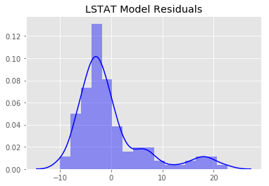

```python
L_residuals = L_Y_test - L_y_predict
sns.distplot(L_residuals,color='b')
plt.title('LSTAT Model Residuals')
```

```
Text(0.5,1,'LSTAT_LOG Model Residuals')
```

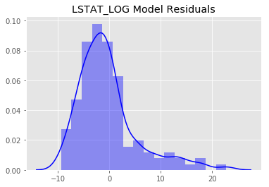

```python
LL_residuals = LL_Y_test - LL_y_predict
sns.distplot(LL_residuals,color='b')
plt.title('LSTAT_LOG Model Residuals')
```

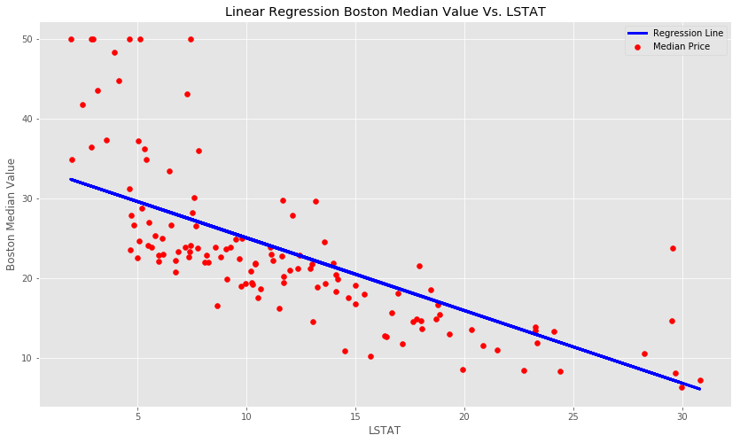

```
The LSTAT coefficient:  -0.91
The LSTAT intercept is 34.12

The LSTAT Mean squared error: 46.286
The LSTAT Mean absolute error: 4.981
The LSTAT Root Mean squared error: 6.803
The LSTAT R2 score: 0.53
```

```python
#X_train, X_test, Y_train, Y_test = train_test_split(X,Y,random_state=1)
# Plot outputs
fig, ax = plt.subplots(figsize=(14,8))
plt.scatter(L_X_test, L_Y_test,  color='red', label = 'Median Price')
plt.plot(L_X_test, L_y_predict, color='blue', linewidth = 3, linestyle= '-',label ='Regression Line')

plt.title("Linear Regression Boston Median Value Vs. LSTAT")
plt.xlabel("LSTAT")
plt.ylabel("Boston Median Value")
plt.legend()
plt.show()

print(f'The LSTAT coefficient:  {L_coefficient[0][0]:.2f}')
print(f'The LSTAT intercept is {L_intercept[0]:.2f}')
print('')
print(f'The LSTAT Mean squared error: {L_model_mse:.3f}')
print(f'The LSTAT Mean absolute error: {L_model_mae:.3f}')
print(f'The LSTAT Root Mean squared error: {L_model_rmse:.3f}')

# Explained variance score: 1 is perfect prediction
print('The LSTAT R2 score: '+ '\033[1m' + '{:.2}''\033[0m'.format(r2_score(L_Y_test,L_y_predict)))
```

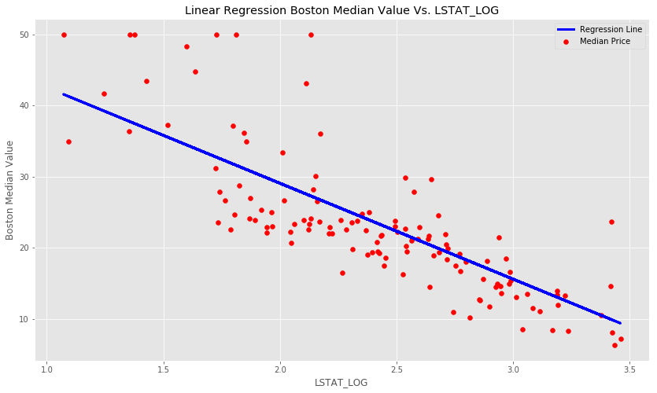

```
LSTAT_LOG coefficient:  -13.49
The LSTAT_LOG intercept is 56.03

The LSTAT_LOG Mean squared error: 34.443
The LSTAT_LOG Mean absolute error: 4.309
The LSTAT_LOG Root Mean squared error: 6.803
The LSTAT_LOG R2 score: 0.65
```

```python
#X_train, X_test, Y_train, Y_test = train_test_split(X,Y,random_state=1)
# Plot outputs
fig, ax = plt.subplots(figsize=(14,8))
plt.scatter(LL_X_test, LL_Y_test,  color='red', label = 'Median Price')
plt.plot(LL_X_test, LL_y_predict, color='blue', linewidth = 3, linestyle= '-',label ='Regression Line')

plt.title("Linear Regression Boston Median Value Vs. LSTAT_LOG")
plt.xlabel("LSTAT_LOG")
plt.ylabel("Boston Median Value")
plt.legend()
plt.show()

print(f'LSTAT_LOG coefficient:  {LL_coefficient[0][0]:.2f}')
print(f'The LSTAT_LOG intercept is {LL_intercept[0]:.2f}')
print('')
print(f'The LSTAT_LOG Mean squared error: {LL_model_mse:.3f}')
print(f'The LSTAT_LOG Mean absolute error: {LL_model_mae:.3f}')
print(f'The LSTAT_LOG Root Mean squared error: {LL_model_rmse:.3f}')

# Explained variance score: 1 is perfect prediction
print('The LSTAT_LOG R2 score: '+ '\033[1m' + '{:.2}''\033[0m'.format(r2_score(LL_Y_test,LL_y_predict)))
```

#### Variable Importance

```python
r2_ = [0.15, 0.13, 0.23, 0.03, 0.18, 0.48, 0.14, 0.06, 0.15,0.22,0.26,0.11,0.54,0.66]
var = ['CRIM','ZN','INDUS','CHAS','NOX','RM','AGE','DIS','RAD','TAX','PTRATIO','B','LSTAT','LSTAT_LOG']
dict2 = {'Variable':var,'R2 Value':r2_}
df2 = pd.DataFrame(dict2)
df2 = df2.sort_values(by='R2 Value', ascending=False)
```

```
Text(0.5,1,'Variable Importance based on LSTAT_LOG Model')
```

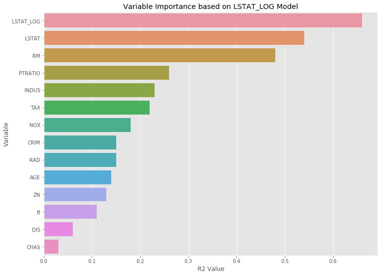

```python
fig, ax = plt.subplots(figsize=(12,9))
sns.barplot(df2['R2 Value'],df2['Variable'])
plt.title('Variable Importance based on LSTAT_LOG Model')
```

# Conclusion

In this analysis, the goal was to see if the Boston housing data reflects commonly held assumptions about general real estate market dynamics. Basic commonly held assumptions of any given real estate market are location matters, better locations will yield a higher home price than a less desirable location, larger homes will also yield a higher home price. Close access to transportation, employment, shopping centers, and other amenities will also yield a higher home price and low crime areas are more desirable than high crime areas.

Additionally, statistical concepts and measures were analyzed to determine the most important variables that contribute to the target variable median home price. The LSTAT variable had the highest predictive value. LSTAT which refers to the proportion of the population who would be considered as having a lower standard of living. Residents who might be characterized as having a lower standard of living would be individuals who have not completed high school or are considered laborers.

It stands to reason that these individuals would earn less money causing them not to be able to afford a home in a more desirable area. The data shows a clear negative correlation between LSTAT and Median Value, as the lower standard of living individuals increase in a geographic area median home values begin to decrease. The assumption regarding larger homes yields higher prices is also reflected by the data and in the second most important feature for determining median home value. The RM variable which refers to the number of rooms in home shows a positive correlation when the number of bedrooms increases the median home value also increases. The third assumption relating to nearby amenities such as transportation, employment, and shopping was represented by the DIS, RAD, and ZN variables.

The DIS variable refers to the weighted distance between the five employment centers in the Boston region, RAD refers to an index of quality and distance of highways and roadways and the ZN variable refers to the proportion of buildings zoned for greater than 25,000 square feet. These three variables had a much lower correlation than anticipated. The ZN variable had a very low correlation, but it is easy to see due to the vagueness of the variable buildings zoned with greater than 25,000 square could be retail, commercial or industrial zones which may have differing impacts on median home value.  
One surprise finding was the importance the pupil to teacher ratio PTRATIO has on determining median home value. This relationship does not appear to have a linear relationship so another model that can handle non-linear relationships might be more useful in determining the validity of this relationship.

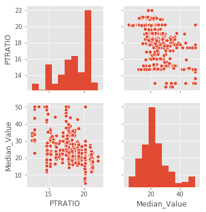

```python
sns.pairplot(df[['PTRATIO','Median_Value']])
```

Finally, a transformation on the LSTAT variable was performed to reduce the skewness to see if this would have a positive impact on the LSTAT variable. The LSTAT variable without transformation produced an $R^2$ score of 0.53 however when a log transformation was performed it increased the $R^2$ value to 0.65. The residuals of LSTAT and LSTAT_LOG were compared and LSTAT_LOG showed a reduction in the overall error rate which validates the fact that performing a log transformation on the LSTAT variable increased the predictive value while also reducing the error rate.

```python
print(f'R2 score for LSTAT: {r2_score(L_Y_test,L_y_predict):.2f}')
print(f'R2 score for LSTAT_LOG: {r2_score(LL_Y_test,LL_y_predict):.2f}')
print('')
print(f'LSTAT Mean squared error: {L_model_mse:.3f}')
print(f'LSTAT_LOG Mean squared error: {LL_model_mse:.3f}')
print('')
print(f'LSTAT Mean absolute error: {L_model_mae:.3f}')
print(f'LSTAT_LOG Mean absolute error: {LL_model_mae:.3f}')
```

```
R2 score for LSTAT: 0.53
R2 score for LSTAT_LOG: 0.65

LSTAT Mean squared error: 46.286
LSTAT_LOG Mean squared error: 34.443

LSTAT Mean absolute error: 4.981
LSTAT_LOG Mean absolute error: 4.309
```